# ANOVA: Exercises

Kateřina Večerková vecerkok@vscht.cz

2025-07-17

# Exercises

## **Exercise 1: One-Way ANOVA**

1. A researcher is studying the effect of three different diets on weight loss. The weights lost (in kg) by individuals on the three diets are as follows:
   - **Diet A**: 3, 4, 5, 6, 4
   - **Diet B**: 2, 3, 4, 3, 2
   - **Diet C**: 6, 7, 8, 7, 6  
     Test whether there is a significant difference in the average weight loss between the three diets at the 5% significance level.

```r
diet_A <- c(3, 4, 5, 6, 4)
diet_B <- c(2, 3, 4, 3, 2)
diet_C <- c(6, 7, 8, 7, 6)

# TODO Your code here
# Combine into a data frame
data <- data.frame(
 weight_loss = c(diet_A, diet_B, diet_C),
 diet = factor(rep(c("A", "B", "C"), each = 5))
)

# Perform one-way ANOVA
anova_result <- aov(weight_loss ~ diet, data = data)
summary(anova_result)
```

```
##             Df Sum Sq Mean Sq F value   Pr(>F)
## diet         2  40.53   20.27   22.52 8.67e-05 ***
## Residuals   12  10.80    0.90
## ---
## Signif. codes:  0 '***' 0.001 '**' 0.01 '*' 0.05 '.' 0.1 ' ' 1
```

## **Exercise 2: Tukey’s HSD Post-Hoc Test**

2. Continuing from the previous exercise, if the ANOVA result shows a significant difference, perform Tukey’s HSD post-hoc test to determine which diets differ from each other.

```r
# TODO Your code here
# Perform Tukey's HSD post-hoc test
tukey_result <- TukeyHSD(anova_result)
tukey_result
```

```
##   Tukey multiple comparisons of means
##     95% family-wise confidence level
##
## Fit: aov(formula = weight_loss ~ diet, data = data)
##
## $diet
##     diff        lwr          upr     p adj
## B-A -1.6 -3.2007182 0.0007181913 0.0501053
## C-A  2.4  0.7992818 4.0007181913 0.0046341
## C-B  4.0  2.3992818 5.6007181913 0.0000634
```

## **Exercise 3: Two-Way ANOVA (Factorial Design)**

3. A researcher is investigating the effect of two factors on exam scores: **study method** (A, B, C) and **gender** (male, female). The exam scores are recorded as follows:
   - **Study Method A (Male)**: 75, 80, 85
   - **Study Method A (Female)**: 78, 82, 86
   - **Study Method B (Male)**: 72, 76, 79
   - **Study Method B (Female)**: 74, 79, 81
   - **Study Method C (Male)**: 70, 73, 77
   - **Study Method C (Female)**: 72, 74, 78

   Perform a two-way ANOVA to test if there is a significant effect of study method, gender, or their interaction on exam scores.

```r
study_method <- factor(rep(c("A", "B", "C"), each = 6))
gender <- factor(rep(c("Male", "Female"), each = 3, times = 3))
exam_scores <- c(75, 80, 85, 78, 82, 86,
                72, 76, 79, 74, 79, 81,
                70, 73, 77, 72, 74, 78)

# TODO Your code here
# Combine into a data frame
data <- data.frame(exam_scores, study_method, gender)

# Perform two-way ANOVA
anova_result <- aov(exam_scores ~ study_method * gender, data = data)
summary(anova_result)
```

```
##                     Df Sum Sq Mean Sq F value Pr(>F)
## study_method         2 148.78   74.39   5.072 0.0253 *
## gender               1  16.06   16.06   1.095 0.3161
## study_method:gender  2   0.78    0.39   0.027 0.9739
## Residuals           12 176.00   14.67
## ---
## Signif. codes:  0 '***' 0.001 '**' 0.01 '*' 0.05 '.' 0.1 ' ' 1
```

## **Exercise 4: Plotting the Interaction Effect**

4. Based on the results of the two-way ANOVA from the previous exercise, create an interaction plot to visualize the effect of **study method** and **gender** on **exam scores**.

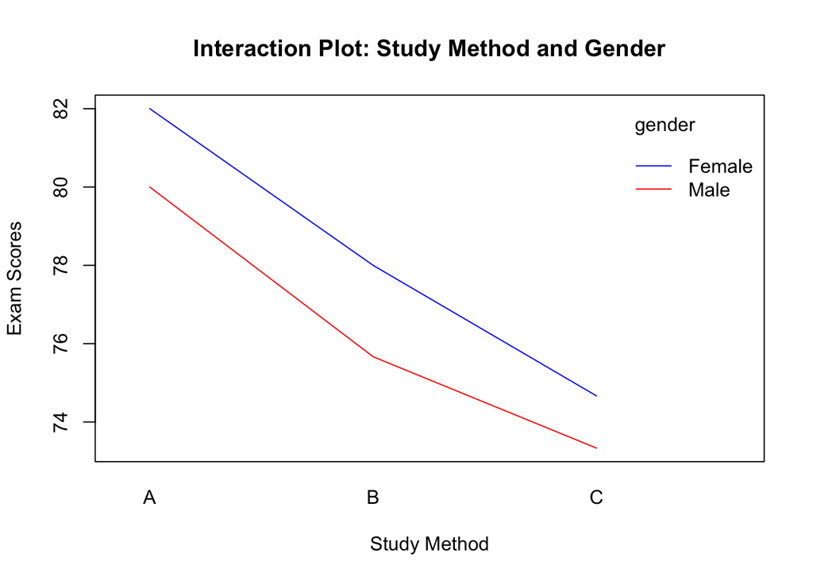

```r
# TODO Your code here
interaction.plot(study_method, gender, exam_scores,
                col = c("blue", "red"),
                lty = 1,
                legend = TRUE,
                xlab = "Study Method",
                ylab = "Exam Scores",
                main = "Interaction Plot: Study Method and Gender")
```

## **Exercise 5: Checking Assumptions (Homogeneity of Variance)**

5. For the ANOVA in **Exercise 1**, check the assumption of homogeneity of variances using **Levene’s Test**. You will need to install and load the `car` package for this.

```r
# TODO Your code here
install.packages("car")
library(car)
data <- data.frame(
 weight_loss = c(diet_A, diet_B, diet_C),
 diet = factor(rep(c("A", "B", "C"), each = 5))
)

# Perform Levene's Test for homogeneity of variances
leveneTest(weight_loss ~ diet, data = data)
```

```
## Levene's Test for Homogeneity of Variance (center = median)
##       Df F value Pr(>F)
## group  2  0.1538 0.8591
##       12
```

## **Exercise 6: ANOVA Interpretation**

6. In an ANOVA experiment, the following results were obtained:
   - **F-statistic** = 4.56
   - **p-value** = 0.015
   - **Significance level** = 0.05

   Based on these results:
   - What is your decision regarding the null hypothesis?
   - Would you perform a post-hoc test? Why or why not?

```r
f_statistic <- 4.56
p_value <- 0.015
alpha <- 0.05

# TODO Your interpretation here
# Decision
if (p_value < alpha) {
   print("Reject H0: There is a significant difference between group means.")
   print("A post-hoc test is needed to identify which groups differ.")
} else {
   print("Fail to reject H0: There is no significant difference between group means.")
   print("No post-hoc test is necessary.")
}
```

```
## [1] "Reject H0: There is a significant difference between group means."
## [1] "A post-hoc test is needed to identify which groups differ."
```

## **Exercise 7: Visualizing ANOVA Results**

7. Using the data from **Exercise 1**, create a boxplot to visualize the weight loss distribution for each diet group.

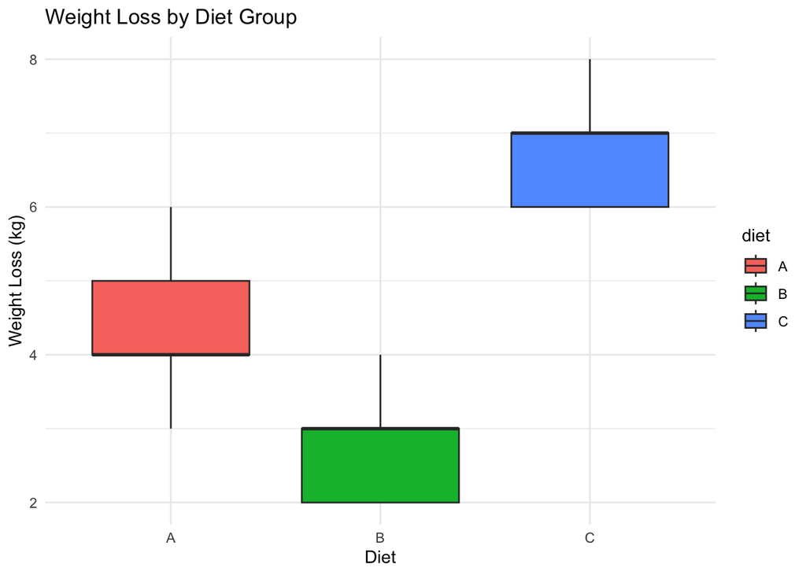

```r
# TODO Your code here
library(ggplot2)

# Boxplot for weight loss by diet
ggplot(data, aes(x = diet, y = weight_loss, fill = diet)) +
 geom_boxplot() +
 labs(title = "Weight Loss by Diet Group",
      x = "Diet",
      y = "Weight Loss (kg)") +
 theme_minimal()
```

## **Exercise 8: ANOVA with More Groups**

8. A company tests four different types of fertilizers (A, B, C, and D) on crop yields (in kg) over five fields. The yields are as follows:
   - **Fertilizer A**: 100, 110, 115, 120, 105
   - **Fertilizer B**: 90, 95, 100, 85, 92
   - **Fertilizer C**: 130, 135, 140, 132, 137
   - **Fertilizer D**: 80, 85, 78, 82, 83

   Test if there is a significant difference in the average crop yield for the four fertilizers using one-way ANOVA at a 5% significance level.

```r
fertilizer_A <- c(100, 110, 115, 120, 105)
fertilizer_B <- c(90, 95, 100, 85, 92)
fertilizer_C <- c(130, 135, 140, 132, 137)
fertilizer_D <- c(80, 85, 78, 82, 83)

# TODO Your code here
# Combine into a data frame
data <- data.frame(
 crop_yield = c(fertilizer_A, fertilizer_B, fertilizer_C, fertilizer_D),
 fertilizer = factor(rep(c("A", "B", "C", "D"), each = 5))
)

# Perform one-way ANOVA
anova_result <- aov(crop_yield ~ fertilizer, data = data)
summary(anova_result)
```

```
##             Df Sum Sq Mean Sq F value   Pr(>F)
## fertilizer   3   8095  2698.3   92.41 2.56e-10 ***
## Residuals   16    467    29.2
## ---
## Signif. codes:  0 '***' 0.001 '**' 0.01 '*' 0.05 '.' 0.1 ' ' 1
```